# FAA flight data exploration

### Top 10 Origin Airports due to Delay Causes

```python
# Helper function to make plots

def plot_delay(by, delay_type, n=10, asc=False):
    df_08.groupby(by)[delay_type].mean().sort_values(ascending=False).head(n)
    sb.barplot(x=df_08.groupby(by)[delay_type].mean().sort_values(ascending=asc).head(n)
               ,y=df_08.groupby(by)[delay_type].mean().sort_values(ascending=asc).head(n).index,
               color='steelblue');
```

#### Top 10 Average Carrier Delay by Origin Airport

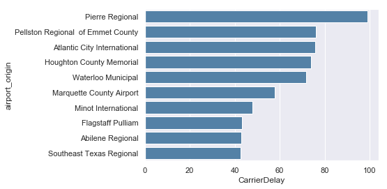

```python
plot_delay(by='airport_origin', delay_type='CarrierDelay')
```

#### Top 10 Average Weather Delay by Origin Airport

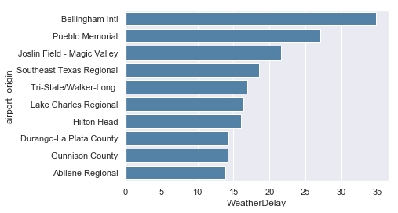

```python
plot_delay(by='airport_origin', delay_type='WeatherDelay')
```

#### Top 10 Average NAS Delay by Origin Airport

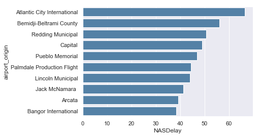

```python
plot_delay(by='airport_origin', delay_type='NASDelay')
```

#### Top 10 Average Security Delay by Origin Airport

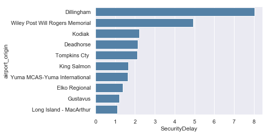

```python
plot_delay(by='airport_origin', delay_type='SecurityDelay')
```

#### Top 10 Average Late Aircraft Delay by Origin Airport

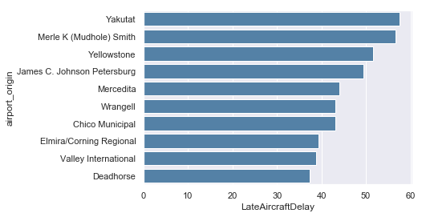

```python
plot_delay(by='airport_origin', delay_type='LateAircraftDelay')
```

### Top 10 Destination Airports due to Delay Causes

#### Top 10 Average Carrier Delay by Destination Airport

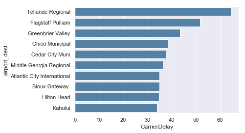

```python
plot_delay(by='airport_dest', delay_type='CarrierDelay')
```

#### Top 10 Average Weather Delay by Destination Airport

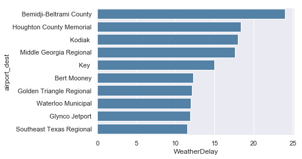

```python
plot_delay(by='airport_dest', delay_type='WeatherDelay')
```

#### Top 10 Average NAS Delay by Destination Airport

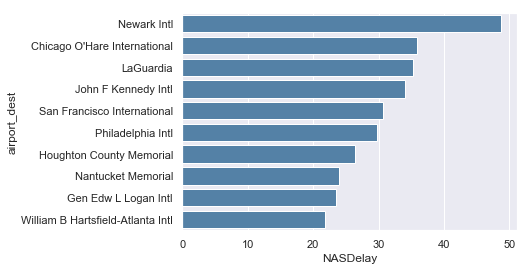

```python
plot_delay(by='airport_dest', delay_type='NASDelay')
```

#### Top 10 Average Security Delay by Destination Airport

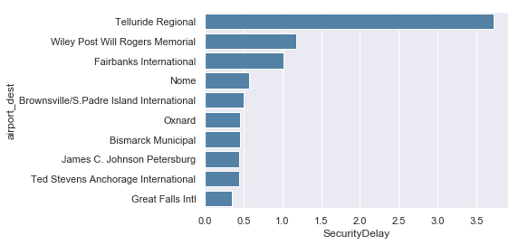

```python
plot_delay(by='airport_dest', delay_type='SecurityDelay')
```

#### Top 10 Average Late Aircraft Delay by Destination Airport

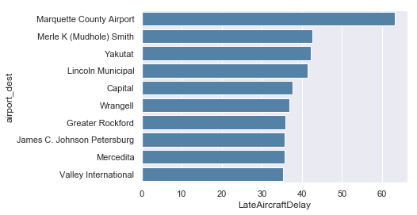

```python
plot_delay(by='airport_dest', delay_type='LateAircraftDelay')
```

### Average arrival and departure delay minutes by month

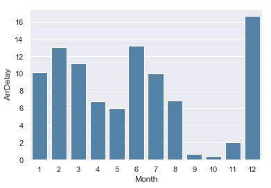

```python
sb.barplot(x=df_08.groupby('Month').ArrDelay.mean().index, color='steelblue',
           y=df_08.groupby('Month').ArrDelay.mean());
```

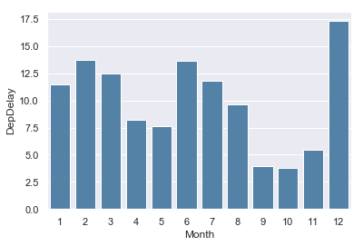

```python
sb.barplot(x=df_08.groupby('Month').DepDelay.mean().index, color='steelblue',
           y=df_08.groupby('Month').DepDelay.mean());
```

As a whole, the amount of delays is the greatest in the month of December, and the least in October. Weather probably plays a factor in this as 4 of the top 5 months where delay is the greatest occurs between December and March.

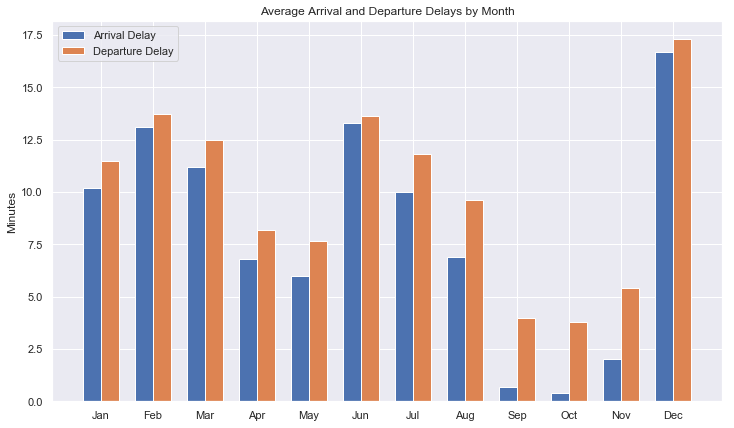

```python
xlabels=['Jan', 'Feb', 'Mar', 'Apr', 'May', 'Jun', 'Jul', 'Aug', 'Sep', 'Oct', 'Nov', 'Dec']
ind = np.arange(len(xlabels))
width = 0.35

plt.figure(figsize = [12, 7])
plt.bar(ind, df_08.groupby(['Month']).mean()['ArrDelay'], width, label='Arrival Delay')
plt.bar(ind + width, df_08.groupby(['Month']).mean()['DepDelay'], width, label='Departure Delay')

plt.ylabel('Minutes')
plt.title('Average Arrival and Departure Delays by Month')

plt.xticks(ind + width / 2, xlabels)
plt.legend(loc='best')
plt.show()
```

### Average arrival and departure delay minutes by day of week

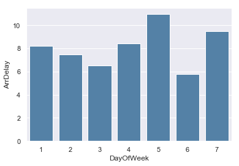

```python
sb.barplot(x=df_08.groupby('DayOfWeek').ArrDelay.mean().index, color='steelblue',
           y=df_08.groupby('DayOfWeek').ArrDelay.mean());
```

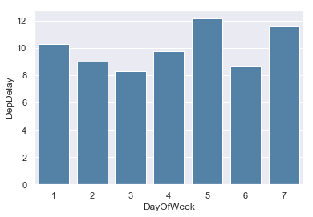

```python
sb.barplot(x=df_08.groupby('DayOfWeek').DepDelay.mean().index, color='steelblue',
           y=df_08.groupby('DayOfWeek').DepDelay.mean());
```

Fridays and Sundays have the greatest amount of delays on average, while Wednesday and Saturday have the least.

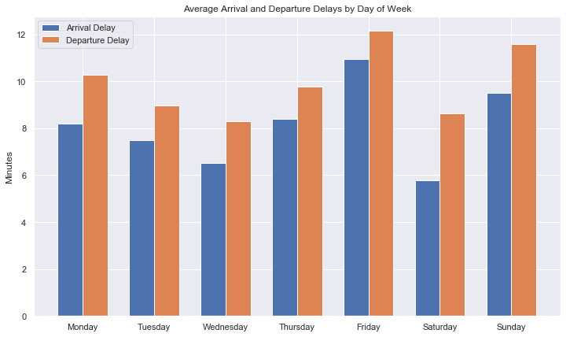

```python
xlabels=['Monday', 'Tuesday', 'Wednesday', 'Thursday', 'Friday', 'Saturday', 'Sunday']
ind = np.arange(len(xlabels))
width = 0.35

plt.figure(figsize = [12, 7])
plt.bar(ind, df_08.groupby(['DayOfWeek']).mean()['ArrDelay'], width, label='Arrival Delay')
plt.bar(ind + width, df_08.groupby(['DayOfWeek']).mean()['DepDelay'], width, label='Departure Delay')

plt.ylabel('Minutes')
plt.title('Average Arrival and Departure Delays by Day of Week')

plt.xticks(ind + width / 2, xlabels)
plt.legend(loc='best')
plt.show()
```

### Average arrival and departure delay minutes by airline

```python
df_08.groupby('Airline')[['CarrierDelay','WeatherDelay','NASDelay',
                          'SecurityDelay','LateAircraftDelay']].mean().reset_index()
```

|  | Airline | CarrierDelay | WeatherDelay | NASDelay | SecurityDelay | LateAircraftDelay |
| --- | --- | --- | --- | --- | --- | --- |
| 0 | AirTran Airways | 7.660308 | 0.637104 | 17.779778 | 0.000000 | 30.583118 |
| 1 | Alaska Airlines | 15.960020 | 1.571083 | 12.570388 | 0.234713 | 19.587379 |
| 2 | Aloha Airlines | 22.149746 | 1.494924 | 2.510152 | 0.269036 | 13.624366 |
| 3 | American Airlines | 17.309765 | 2.568192 | 18.324413 | 0.040644 | 20.454338 |
| 4 | American Eagle Airlines | 15.001680 | 3.669936 | 17.141478 | 0.010310 | 22.908693 |
| 5 | Atlantic Southeast Airlines | 25.375898 | 8.492953 | 16.946573 | 0.053472 | 9.813471 |
| 6 | Comair | 20.477520 | 12.807838 | 20.774279 | 0.024403 | 3.117828 |
| 7 | Continental Air Lines | 13.637261 | 2.741824 | 26.250319 | 0.155954 | 17.169931 |
| 8 | Delta Air Lines | 14.277822 | 1.690854 | 19.680231 | 0.013810 | 16.189377 |
| 9 | Expressjet Airlines | 13.859438 | 2.816085 | 23.609844 | 0.149892 | 22.331715 |
| 10 | Frontier Airlines | 12.708679 | 1.082135 | 18.044056 | 0.019799 | 9.488708 |
| 11 | Hawaiian Airlines | 33.074791 | 0.869744 | 0.166577 | 0.036321 | 14.718375 |
| 12 | JetBlue Airways | 13.766349 | 1.121874 | 26.604271 | 0.042683 | 26.272982 |
| 13 | Mesa Airlines | 32.590702 | 3.164176 | 14.779746 | 0.154218 | 13.964683 |
| 14 | Northwest Airlines | 19.143814 | 4.002784 | 16.849348 | 0.058484 | 11.108562 |
| 15 | Pinnacle Airlines | 19.864634 | 3.263802 | 14.492992 | 0.033956 | 19.808550 |
| 16 | Skywest Airlines | 15.945803 | 2.910390 | 17.386831 | 0.116747 | 22.384132 |
| 17 | Southwest Airlines | 10.288646 | 2.323771 | 7.820192 | 0.117498 | 30.083830 |
| 18 | US Airways | 13.376280 | 1.228257 | 18.905851 | 0.131431 | 16.599266 |
| 19 | United Air Lines | 14.819681 | 1.844820 | 17.636993 | 0.014310 | 27.856356 |

```python
df_08.groupby('Airline').WeatherDelay.mean().head().reset_index()
```

|  | Airline | WeatherDelay |
| --- | --- | --- |
| 0 | AirTran Airways | 0.637104 |
| 1 | Alaska Airlines | 1.571083 |
| 2 | Aloha Airlines | 1.494924 |
| 3 | American Airlines | 2.568192 |
| 4 | American Eagle Airlines | 3.669936 |

```python
df_08.groupby('Airline').NASDelay.mean().head().reset_index()
```

|  | Airline | NASDelay |
| --- | --- | --- |
| 0 | AirTran Airways | 17.779778 |
| 1 | Alaska Airlines | 12.570388 |
| 2 | Aloha Airlines | 2.510152 |
| 3 | American Airlines | 18.324413 |
| 4 | American Eagle Airlines | 17.141478 |

```python
df_08.groupby('Airline').SecurityDelay.mean().head().reset_index()
```

|  | Airline | SecurityDelay |
| --- | --- | --- |
| 0 | AirTran Airways | 0.000000 |
| 1 | Alaska Airlines | 0.234713 |
| 2 | Aloha Airlines | 0.269036 |
| 3 | American Airlines | 0.040644 |
| 4 | American Eagle Airlines | 0.010310 |

```python
df_08.groupby('Airline').LateAircraftDelay.mean().head().reset_index()
```

|  | Airline | LateAircraftDelay |
| --- | --- | --- |
| 0 | AirTran Airways | 30.583118 |
| 1 | Alaska Airlines | 19.587379 |
| 2 | Aloha Airlines | 13.624366 |
| 3 | American Airlines | 20.454338 |
| 4 | American Eagle Airlines | 22.908693 |

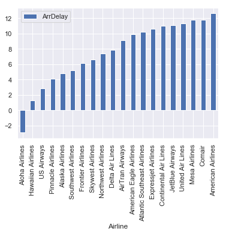

```python
df_08.groupby('Airline').agg({'ArrDelay':'mean'}).sort_values(by='ArrDelay').plot.bar()
plt.show()
```

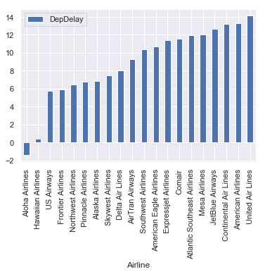

```python
df_08.groupby('Airline').agg({'DepDelay':'mean'}).sort_values(by='DepDelay').plot.bar()
plt.show()
```

```python
# Generate mean arrival and departure delay dataframe grouped by airlines
airline_mean_arrdelay = df_08.groupby('Airline',as_index=False).ArrDelay.mean().sort_values(by='ArrDelay',ascending=False)
airline_mean_depdelay = df_08.groupby('Airline',as_index=False).DepDelay.mean().sort_values(by='DepDelay',ascending=False)
airline_mean_carrierdelay = df_08.groupby('Airline',as_index=False).CarrierDelay.mean().sort_values(by='CarrierDelay',
                                                                                                    ascending=False)
```

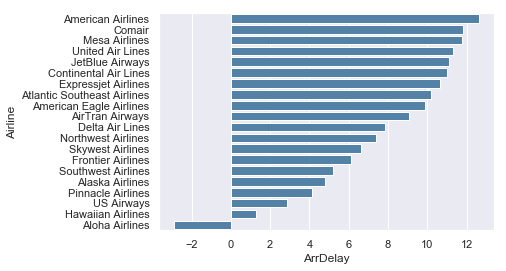

```python
sb.barplot(x=airline_mean_arrdelay.ArrDelay, y=airline_mean_arrdelay.Airline, color='steelblue');
```

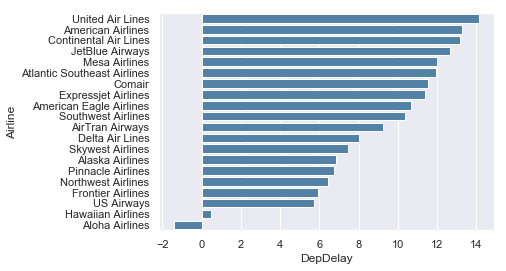

```python
sb.barplot(x=airline_mean_depdelay.DepDelay, y=airline_mean_depdelay.Airline, color='steelblue');
```

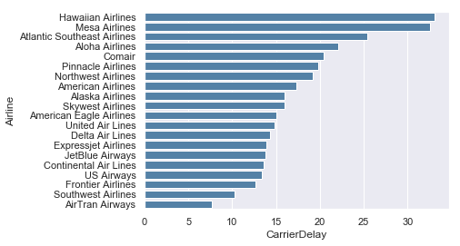

```python
sb.barplot(x=airline_mean_carrierdelay.CarrierDelay, y=airline_mean_carrierdelay.Airline, color='steelblue');
```

### Top 15 Average Delays by State

#### Departure Delays by Origin State

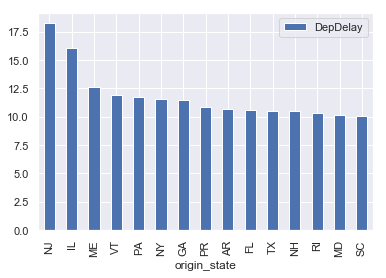

```python
df_08.groupby('origin_state').agg({'DepDelay':'mean'}).sort_values(by='DepDelay',ascending=False).head(15).plot.bar()
plt.show()
```

#### Arrival Delays by Destination State

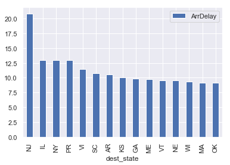

```python
df_08.groupby('dest_state').agg({'ArrDelay':'mean'}).sort_values(by='ArrDelay',ascending=False).head(15).plot.bar()
plt.show()
```

It would interesting to plot these on a map to see it visually. From a glance I see that the states in the east coast (NJ, NY) and midwest (IL) gets hit with a lot of delays. Suprisingly, I don't see any west coast states in the top 10 list.

### Average arrival delay minutes breakdown by cause (with arrival delay 15 minutes or more)

Note: This only takes into consideration flights with ArrDelay equal or greater than 15 minutes. The delay cause minutes are not reported for ArrDelay of less than 15 minutes and are NaN in the dataset.

```python
def plot_delay_type(by,busy_airports=False,n=10):

    if busy_airports:
        top_n = df_08['airport_dest'].value_counts().iloc[:n].index.tolist()
        busiest_airports = df_08[df_08['airport_dest'].isin(top_n)]
        df_plot = busiest_airports.groupby(by)[['CarrierDelay','WeatherDelay','NASDelay',
                          'SecurityDelay','LateAircraftDelay']].mean().reset_index().set_index(by)
    else:
        # Create df_plot for plotting purposes
        df_plot = df_08.groupby(by)[['CarrierDelay','WeatherDelay','NASDelay',
                          'SecurityDelay','LateAircraftDelay']].mean().reset_index().set_index(by)

    # Create new column adding up all cancellation summary values
    df_plot['temp'] = df_plot['CarrierDelay'] + df_plot['WeatherDelay'] + df_plot['NASDelay'] + df_plot['SecurityDelay'] + df_plot['LateAircraftDelay']

    # Sort by descending total number of cancellations in TotalCancel column
    df_plot = df_plot.sort_values(by = 'temp', ascending=False).head(n)

    # Drop the TotalCancel column so it won't be plotted
    df_plot.drop(columns = 'temp',inplace=True)

    # Reverse the dataframe so that the horizontal plot will plot the maximum from top instead of bottom
    df_plot = df_plot.iloc[::-1]

    #N = 5
    CDelay = df_plot['CarrierDelay']
    WDelay = df_plot['WeatherDelay']
    NDelay = df_plot['NASDelay']
    SDelay = df_plot['SecurityDelay']
    LDelay = df_plot['LateAircraftDelay']

    ind = np.arange(n)    # the x locations for the groups
    width = 0.5       # the width of the bars: can also be len(x) sequence

    sb.set(style='whitegrid', font_scale=1.2)
    plt.figure(figsize = [10, 7])
    p1 = plt.barh(ind, CDelay, width, color='#003f5c')
    p2 = plt.barh(ind, WDelay, width, left=CDelay, color='#58508d')
    p3 = plt.barh(ind, NDelay, width, left=WDelay+CDelay, color='#bc5090')
    p4 = plt.barh(ind, SDelay, width, left=WDelay+CDelay+NDelay, color='#ff6361')
    p5 = plt.barh(ind, LDelay, width, left=WDelay+CDelay+NDelay+SDelay, color='#ffa600')

    plt.xlabel('Minutes')
    plt.title('Average Arrival Delay in Minutes with Delay Type')
    plt.yticks(ind, df_plot.index)
    plt.xticks(np.arange(0, 70, 10))
    plt.legend((p1[0], p2[0], p3[0], p4[0], p5[0]), df_plot.columns, loc='lower right')

    plt.show()
```

```python
# Helper function to generate plots to show average arrival delay and causes
#for flights with arrival delay >=15

def plot_delay_cause(by,top30=False,n=10):  # count default is 10

    if top30:
        n = 30
        # Create df_plot for plotting purposes
        df_plot = busiest_airports.groupby(by)[['CarrierDelay','WeatherDelay','NASDelay',
                          'SecurityDelay','LateAircraftDelay']].mean().reset_index().set_index(by)
    else:

        df_plot = df_08.groupby(by)[['CarrierDelay','WeatherDelay','NASDelay',
                          'SecurityDelay','LateAircraftDelay']].mean().reset_index().set_index(by)

    # Create new column adding up all cancellation summary values
    df_plot['temp'] = df_plot['CarrierDelay'] + df_plot['WeatherDelay'] + df_plot['NASDelay'] + df_plot['SecurityDelay'] + df_plot['LateAircraftDelay']

    # Sort by descending total number of cancellations in TotalCancel column
    df_plot = df_plot.sort_values(by = 'temp',ascending=False).head(n)

    # Drop the TotalCancel column so it won't be plotted
    df_plot.drop(columns = 'temp',inplace=True)

    # Generate plot
    df_plot.plot(kind='bar', stacked=True);
```

#### Plot by Airline

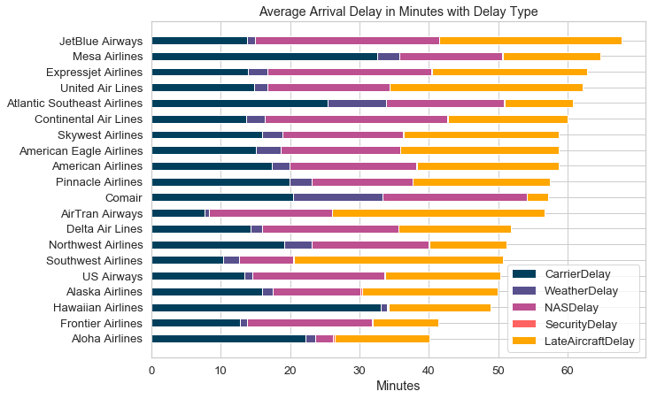

```python
plot_delay_type('Airline',n=20)
```

#### Plot by Destination Airport

Sorted by amount of arrival delay minutes

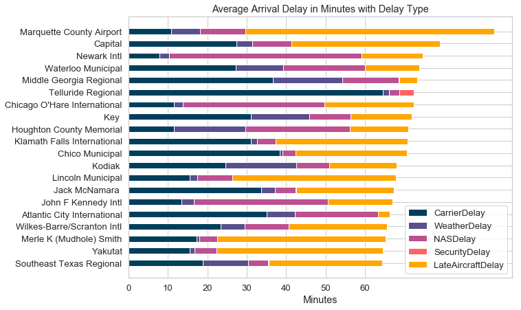

```python
plot_delay_type(by='airport_dest',busy_airports=False,n=20)
```

Below we have a plot that only includes the top 20 airports in the US in terms of number of scheduled flights to give a better picture of the average arrival delays where most people tend to fly to.

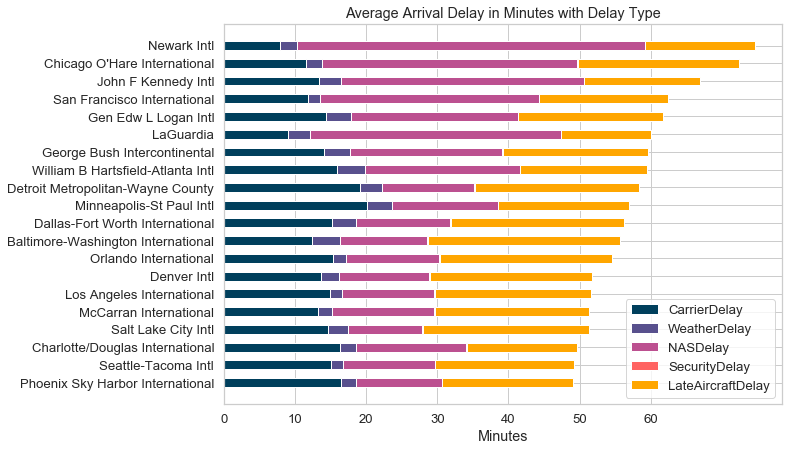

```python
plot_delay_type(by='airport_dest',busy_airports=True,n=20)
```

#### Plot by Destination State

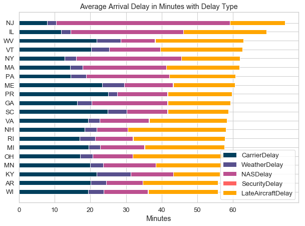

```python
plot_delay_type('dest_state',n=20)
```

### Average arrival delay minutes by scheduled arrival hour

```python
df_08.groupby('arr_hour').ArrDelay.mean().nlargest(5)
```

```
arr_hour
22    14.488495
21    14.307870
20    13.995308
19    13.862139
23    13.380361
Name: ArrDelay, dtype: float32
```

```python
df_08.groupby('arr_hour').ArrDelay.mean().nsmallest(5)
```

```
arr_hour
7     0.629113
8     1.234562
6     1.443206
9     1.870786
10    2.825254
Name: ArrDelay, dtype: float32
```

```python
df_08.groupby('dep_hour').ArrDelay.mean().nlargest(5)
```

```
dep_hour
20    14.607615
18    14.486720
19    14.066807
17    13.734726
21    12.686222
Name: ArrDelay, dtype: float32
```

```python
df_08.groupby('dep_hour').ArrDelay.mean().nsmallest(5)
```

```
dep_hour
1    0.232508
2    0.394015
6    0.424862
0    0.813482
5    0.955406
Name: ArrDelay, dtype: float32
```

```python
sb.set(font_scale=1)
```

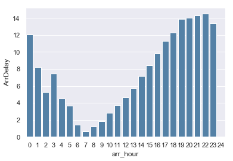

```python
sb.barplot(x=df_08.groupby('arr_hour').ArrDelay.mean().index, color='steelblue',
           y=df_08.groupby('arr_hour').ArrDelay.mean());
```

### Average departure delay minutes by scheduled departure hour

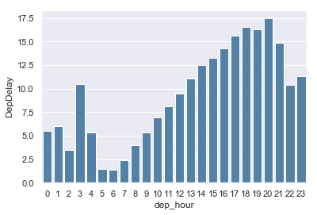

```python
sb.barplot(x=df_08.groupby('dep_hour').DepDelay.mean().index, color='steelblue',
           y=df_08.groupby('dep_hour').DepDelay.mean());
```

Putting DepDelay and ArrDelay together within same plot below.

The worst time in terms of flight delays is between between the hours of 5pm and 8pm, and it also makes sense that the least delay occurs between the 5am and 7am hours.

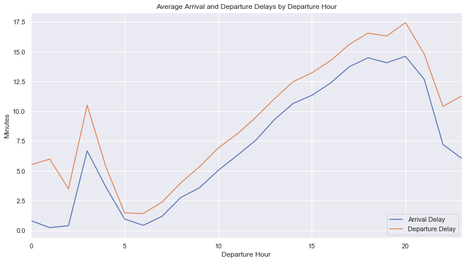

```python
fig, ax = plt.subplots(figsize=(13,7))
df_08.groupby(['dep_hour']).mean()['ArrDelay'].plot(ax=ax)
df_08.groupby(['dep_hour']).mean()['DepDelay'].plot(ax=ax)
plt.title('Average Arrival and Departure Delays by Departure Hour')
plt.xlabel('Departure Hour')
plt.ylabel('Minutes')
plt.legend(['Arrival Delay','Departure Delay'], loc='lower right');
```

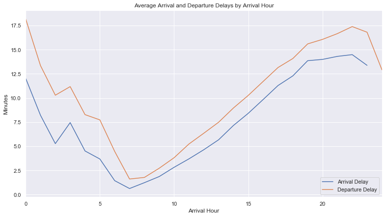

```python
fig, ax = plt.subplots(figsize=(13,7))
df_08.groupby(['arr_hour']).mean()['ArrDelay'].plot(ax=ax)
df_08.groupby(['arr_hour']).mean()['DepDelay'].plot(ax=ax)
plt.title('Average Arrival and Departure Delays by Arrival Hour')
plt.xlabel('Arrival Hour')
plt.ylabel('Minutes')
plt.legend(['Arrival Delay','Departure Delay'], loc='lower right');
```

### Origin Airports vs Number of Cancellations

Looking at the number of flight cancellations by origin airports, Chicago O'Hare has a significantly higher number of cancellations out of the top 10 airports, followed by Dallas-Forth Worth and Atlanta.

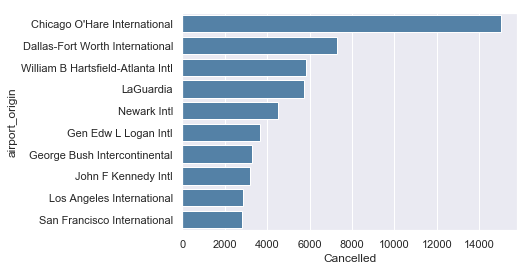

```python
sb.barplot(x=df_08.groupby('airport_origin').Cancelled.sum().sort_values(ascending=False).head(10)
           , y=df_08.groupby('airport_origin').Cancelled.sum().sort_values(ascending=False).head(10).index, color='steelblue');
```

### Origin Airports vs Number of Diverted Flights

There were much less diverted flights compared to cancelled flights. The top 3 is still dominated by Atlanta, Chicago, and Dallas-Fort Worth.

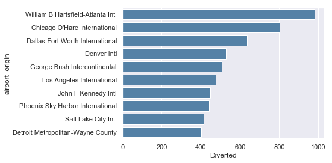

```python
sb.barplot(x=df_08.groupby('airport_origin').Diverted.sum().sort_values(ascending=False).head(10)
           , y=df_08.groupby('airport_origin').Diverted.sum().sort_values(ascending=False).head(10).index, color='steelblue');
```

### Diverted Flights vs Scheduled Date

```python
diverted_flights = df_08[df_08['Diverted']==1]
```

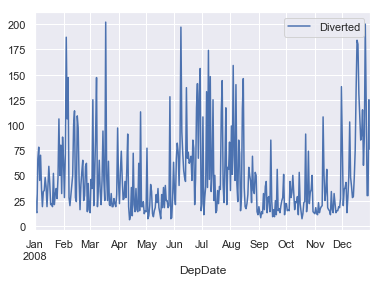

```python
diverted_flights[['DepDate','Diverted']].groupby(['DepDate']).sum().plot()
plt.show()
```

#### Summarizing by month

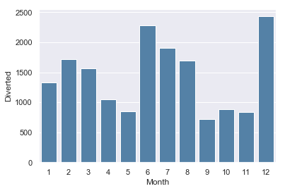

```python
sb.barplot(x=df_08.groupby('Month').Diverted.sum().index, color='steelblue',
           y=df_08.groupby('Month').Diverted.sum());
```

Number of diverted flights peaked in December, and also in June. I think this may be due to the winter weather in December and the hurricanes and tornadoes in the summer

### Top 10 Airports for Number of Cancelled Flights

```python
df_08.groupby(['CancellationCode', 'Airline']).size().reset_index().pivot(columns='CancellationCode',
                                                                                   index='Airline', values=0)
```

| CancellationCode Airline | Carrier | NAS | Security | Weather |
| --- | --- | --- | --- | --- |
| AirTran Airways | 815.0 | 445.0 | NaN | 976.0 |
| Alaska Airlines | 1222.0 | 52.0 | NaN | 865.0 |
| Aloha Airlines | 42.0 | NaN | NaN | NaN |
| American Airlines | 9609.0 | 2334.0 | 2.0 | 5495.0 |
| American Eagle Airlines | 3644.0 | 6275.0 | 4.0 | 8408.0 |
| Atlantic Southeast Airlines | 1384.0 | 1357.0 | 2.0 | 2283.0 |
| Comair | 1328.0 | 118.0 | NaN | 5016.0 |
| Continental Air Lines | 746.0 | 78.0 | NaN | 2878.0 |
| Delta Air Lines | 3113.0 | 1417.0 | NaN | 2283.0 |
| Expressjet Airlines | 697.0 | 3871.0 | NaN | 5424.0 |
| Frontier Airlines | 109.0 | 2.0 | NaN | 192.0 |
| Hawaiian Airlines | 563.0 | NaN | NaN | 7.0 |
| JetBlue Airways | 665.0 | 95.0 | NaN | 2445.0 |
| Mesa Airlines | 5020.0 | 2433.0 | NaN | 1766.0 |
| Northwest Airlines | 1119.0 | 886.0 | NaN | 901.0 |
| Pinnacle Airlines | 4329.0 | 838.0 | 1.0 | 1932.0 |
| Skywest Airlines | 3162.0 | 4525.0 | 1.0 | 4748.0 |
| Southwest Airlines | 6554.0 | 666.0 | 2.0 | 5167.0 |
| US Airways | 3857.0 | 1594.0 | NaN | 1131.0 |
| United Air Lines | 6352.0 | 1202.0 | NaN | 2987.0 |

```python
# Helper function to generate cancellation code plots

def plot_cancel_v(by,n=10,sorted=True, order='top'):     # count default is 10
    # Create df_plot for plotting purposes
    df_plot = df_08.groupby(['CancellationCode', by]).size().reset_index().pivot(columns='CancellationCode',
                                                                                   index=by, values=0)
    # Fill NaN with zeros
    df_plot.fillna(0, inplace = True)

    # Create new column adding up all cancellation summary values
    df_plot['TotalCancel'] = df_plot['Carrier'] + df_plot['NAS'] + df_plot['Security'] + df_plot['Weather']

    if sorted and order=='top':
        # Sort by descending total number of cancellations in TotalCancel column
        df_plot = df_plot.sort_values(by = 'TotalCancel',ascending=False).head(n)
    elif sorted and order=='bottom':
        # Sort by ascending total number of cancellations in TotalCancel column
        df_plot = df_plot.sort_values(by = 'TotalCancel',ascending=True).head(n)
    else:
        # Values are not sorted, useful for ordinal variables
        df_plot = df_plot.head(n)

    # Drop the TotalCancel column so it won't be plotted
    df_plot.drop(columns = 'TotalCancel',inplace=True)

    # Generate plot
    df_plot.plot(kind='bar', stacked=True);
```

```python
def plot_cancel_h(by,n=10,sorted=True, order='top'):     # count default is 10
    # Create df_plot for plotting purposes
    df_plot = df_08.groupby(['CancellationCode', by]).size().reset_index().pivot(columns='CancellationCode',
                                                                                   index=by, values=0)
    # Fill NaN with zeros
    df_plot.fillna(0, inplace = True)

    # Create new column adding up all cancellation summary values
    df_plot['TotalCancel'] = df_plot['Carrier'] + df_plot['NAS'] + df_plot['Security'] + df_plot['Weather']

    if sorted and order=='top':
        # Sort by descending total number of cancellations in TotalCancel column
        df_plot = df_plot.sort_values(by = 'TotalCancel',ascending=False).head(n)
    elif sorted and order=='bottom':
        # Sort by ascending total number of cancellations in TotalCancel column
        df_plot = df_plot.sort_values(by = 'TotalCancel',ascending=True).head(n)
    else:
        # Values are not sorted, useful for ordinal variables
        df_plot = df_plot.head(n)

    # Get maximum value for x axis number so that the axis is labelled with proper range
    x_max = (df_plot['TotalCancel'].iloc[0])

    # Drop the TotalCancel column so it won't be plotted
    df_plot.drop(columns = 'TotalCancel',inplace=True)

    # Reverse the dataframe so that the horizontal plot will plot the maximum from top instead of bottom
    df_plot = df_plot.iloc[::-1]

    # Generate plot
    #N = 4
    Carrier = df_plot['Carrier']
    NAS = df_plot['NAS']
    Security = df_plot['Security']
    Weather = df_plot['Weather']

    ind = np.arange(n)    # the x locations for the groups
    width = 0.5       # the width of the bars: can also be len(x) sequence

    sb.set(style='whitegrid', font_scale=1.2)
    plt.figure(figsize = [10, 7])
    p1 = plt.barh(ind, Carrier, width)
    p2 = plt.barh(ind, NAS, width, left=Carrier)
    p3 = plt.barh(ind, Security, width, left=Carrier+NAS)
    p4 = plt.barh(ind, Weather, width, left=Carrier+NAS+Security)



    plt.xlabel('Count')
    plt.title('Number of Flight Cancellations')
    plt.yticks(ind, df_plot.index)

    plt.xticks(np.arange(0, x_max, 2000))
    plt.legend((p1[0], p2[0], p3[0], p4[0]), df_plot.columns, loc='lower right', title='Cancellation Code')

    plt.show()
```

```python
def plot_cancel_code(by,n=10,sorted=True, order='top', orientation='h'):     # count default is 10
    # Create df_plot for plotting purposes
    df_plot = df_08.groupby(['CancellationCode', by]).size().reset_index().pivot(columns='CancellationCode',
                                                                                   index=by, values=0)
    # Fill NaN with zeros
    df_plot.fillna(0, inplace = True)

    # Create new column adding up all cancellation summary values
    df_plot['TotalCancel'] = df_plot['Carrier'] + df_plot['NAS'] + df_plot['Security'] + df_plot['Weather']

    if sorted and order=='top':
        # Sort by descending total number of cancellations in TotalCancel column
        df_plot = df_plot.sort_values(by = 'TotalCancel',ascending=False).head(n)
    elif sorted and order=='bottom':
        # Sort by ascending total number of cancellations in TotalCancel column
        df_plot = df_plot.sort_values(by = 'TotalCancel',ascending=True).head(n)
    else:
        # Values are not sorted, useful for ordinal variables
        df_plot = df_plot.head(n)

    if orientation == 'h':
        # Get maximum value for x axis number so that the axis is labelled with proper range
        x_max = (df_plot['TotalCancel'].iloc[0])

        # Drop the TotalCancel column so it won't be plotted
        df_plot.drop(columns = 'TotalCancel',inplace=True)

        # Reverse the dataframe so that the horizontal plot will plot the maximum from top instead of bottom
        df_plot = df_plot.iloc[::-1]

        # Generate plot

        Carrier = df_plot['Carrier']
        NAS = df_plot['NAS']
        Security = df_plot['Security']
        Weather = df_plot['Weather']

        ind = np.arange(n)    # the x locations for the groups
        width = 0.5       # the width of the bars: can also be len(x) sequence

        sb.set(style='whitegrid', font_scale=1.2)
        plt.figure(figsize = [10, 7])
        p1 = plt.barh(ind, Carrier, width, color='#004c6d')
        p2 = plt.barh(ind, NAS, width, left=Carrier, color='#5d8ba9')
        p3 = plt.barh(ind, Security, width, left=Carrier+NAS, color='#8eb8d3')
        p4 = plt.barh(ind, Weather, width, left=Carrier+NAS+Security, color='#c1e7ff')

        plt.xlabel('Count')
        plt.title('Number of Flight Cancellations')

        if by == 'Month':
            ylabels = ['Jan', 'Feb', 'Mar', 'Apr', 'May', 'Jun', 'Jul', 'Aug', 'Sep', 'Oct', 'Nov', 'Dec']
            ylabels.reverse()
            plt.yticks(ind, ylabels)
        elif by == 'DayOfWeek':
            ylabels = ['Monday', 'Tuesday', 'Wednesday', 'Thursday', 'Friday', 'Saturday', 'Sunday']
            ylabels.reverse()
            plt.yticks(ind, ylabels)
        else:
            plt.yticks(ind, df_plot.index)

        plt.xticks(np.arange(0, x_max, 2000))
        plt.legend((p1[0], p2[0], p3[0], p4[0]), df_plot.columns, loc='best', title='Cancellation Code')

    elif orientation == 'v':
        # Drop the TotalCancel column so it won't be plotted
        df_plot.drop(columns = 'TotalCancel',inplace=True)

        # Generate plot

        Carrier = df_plot['Carrier']
        NAS = df_plot['NAS']
        Security = df_plot['Security']
        Weather = df_plot['Weather']

        ind = np.arange(n)    # the x locations for the groups
        width = 0.5       # the width of the bars: can also be len(x) sequence

        sb.set(style='whitegrid', font_scale=1.2)
        plt.figure(figsize = [10, 7])
        p1 = plt.bar(ind, Carrier, width, color='#004c6d')
        p2 = plt.bar(ind, NAS, width, bottom=Carrier, color='#5d8ba9')
        p3 = plt.bar(ind, Security, width, bottom=Carrier+NAS, color='#8eb8d3')
        p4 = plt.bar(ind, Weather, width, bottom=Carrier+NAS+Security, color='#c1e7ff')
        plt.ylabel('Count')
        plt.title('Number of Flight Cancellations')
        if by == 'Month':
            xlabels = ['Jan', 'Feb', 'Mar', 'Apr', 'May', 'Jun', 'Jul', 'Aug', 'Sep', 'Oct', 'Nov', 'Dec']
            #ylabels.reverse()
            plt.xticks(ind, xlabels)
        else:
            plt.xticks(ind, df_plot.index)
        plt.legend((p1[0], p2[0], p3[0], p4[0]), df_plot.columns, loc='best', title='Cancellation Code')

    plt.show();
```

```python
df_08.groupby('Origin').Cancelled.sum().sort_values(ascending=False).head(10)
```

```
Origin
ORD    15050.0
DFW     7272.0
ATL     5830.0
LGA     5753.0
EWR     4511.0
BOS     3655.0
IAH     3261.0
JFK     3196.0
LAX     2838.0
SFO     2790.0
Name: Cancelled, dtype: float64
```

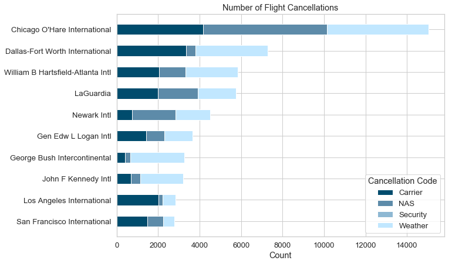

```python
plot_cancel_code('airport_origin')
```